# Time series - decomposition

data should be extracted 12 interval monthly data about number of passngers for 12 years

```r
data("AirPassengers")
AP <- AirPassengers
str(AP)
```

```
 Time-Series [1:144] from 1949 to 1961: 112 118 132 129 121 135 148 148 136 119 ...
```

```r
head(AP)
```

```
[1] 112 118 132 129 121 135
```

```r
ts(AP, frequency = 12, start = c(1949,1))
```

```
     Jan Feb Mar Apr May Jun Jul Aug Sep Oct Nov Dec
1949 112 118 132 129 121 135 148 148 136 119 104 118
1950 115 126 141 135 125 149 170 170 158 133 114 140
1951 145 150 178 163 172 178 199 199 184 162 146 166
1952 171 180 193 181 183 218 230 242 209 191 172 194
1953 196 196 236 235 229 243 264 272 237 211 180 201
1954 204 188 235 227 234 264 302 293 259 229 203 229
1955 242 233 267 269 270 315 364 347 312 274 237 278
1956 284 277 317 313 318 374 413 405 355 306 271 306
1957 315 301 356 348 355 422 465 467 404 347 305 336
1958 340 318 362 348 363 435 491 505 404 359 310 337
1959 360 342 406 396 420 472 548 559 463 407 362 405
1960 417 391 419 461 472 535 622 606 508 461 390 432
```

```r
attributes(AP)
```

```
$tsp
[1] 1949.000 1960.917   12.000

$class
[1] "ts"
```

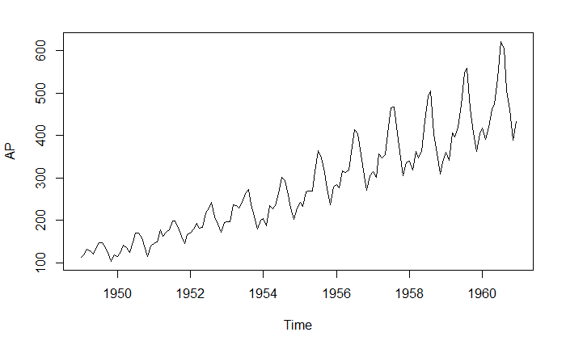

```r
plot(AP)
```

there is an increasing trend but also some seasonality can be seen. the spans in initial series is smaller than toward which make time series non stationary therefore we apply log transformation

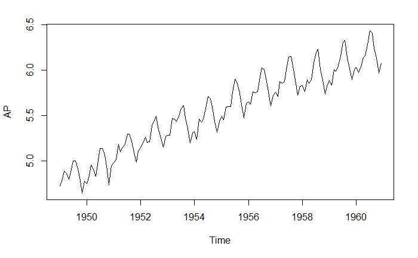

```r
AP <- log(AP)
plot(AP)
```

The fluctuation now is less between spans

Decomposition a summary of time series figure is for estimated the seasonal figure only

```r
decomp <- decompose(AP)
decomp$figure
```

```
 [1] -0.085815019 -0.114412848  0.018113355 -0.013045611 -0.008966106  0.115392997  0.210816435  0.204512399  0.064836351 -0.075271265
[11] -0.215845612 -0.100315075
```

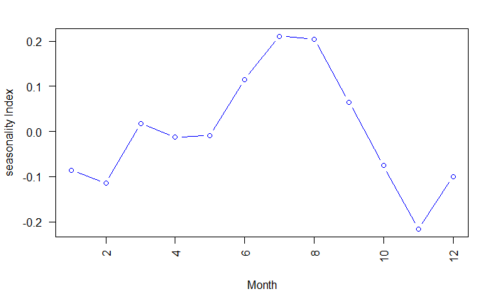

```r
plot(decomp$figure,
     type='b',
     xlab='Month',
     ylab='seasonality Index',
     col='blue',
     las=2)
```

for showing trend, seasonal, and random simply

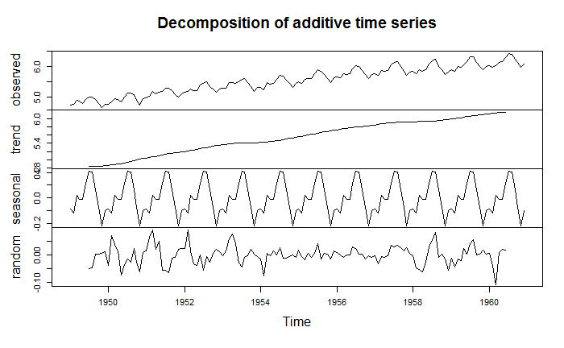

```r
plot(decomp)
```

package

```r
install.packages("forecast")
```

Autoregression integerated moving average ACF and PACF plots ljung-box test

```r
library(forecast)
model <- auto.arima(AP)
model
```

```
Series: AP
ARIMA(0,1,1)(0,1,1)[12]

Coefficients:
          ma1     sma1
      -0.4018  -0.5569
s.e.   0.0896   0.0731

sigma^2 estimated as 0.001371:  log likelihood=244.7
AIC=-483.4   AICc=-483.21   BIC=-474.77
```

```r
attributes(model)
```

```
$names
 [1] "coef"      "sigma2"    "var.coef"  "mask"      "loglik"    "aic"       "arma"      "residuals" "call"      "series"
[11] "code"      "n.cond"    "nobs"      "model"     "bic"       "aicc"      "x"         "fitted"

$class
[1] "forecast_ARIMA" "ARIMA"          "Arima"
```

```r
model$coef
```

```
       ma1       sma1
-0.4018280 -0.5569448
```

(0,1,1) p:ar order, d:degree of differencing, q:Moving average order

ACF and PACF plots

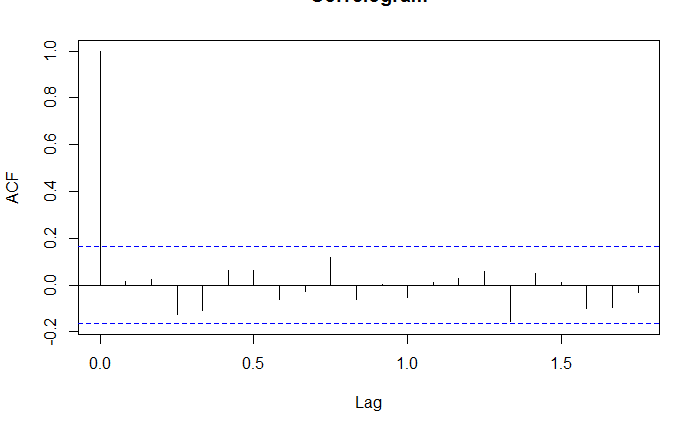

```r
acf(model$residuals, main='Correlogram')
```

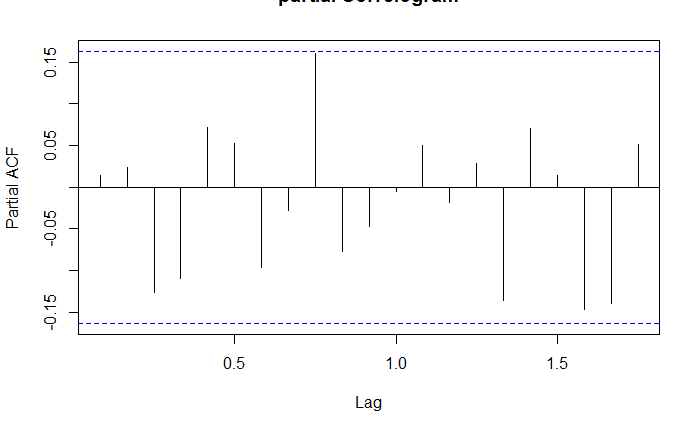

```r
pacf(model$residuals, main='partial Correlogram')
```

Ljung-box test

```r
Box.test(model$residuals, lag=20, type = 'Ljung-Box')
```

```
    Box-Ljung test

data:  model$residuals
X-squared = 17.688, df = 20, p-value = 0.6079
```

since the p value is more than 0.05 there is little chance for nonzero autocorrelation or we dont have any autocorrelation

just for conefirming no problem with the model residual plot we are looking a bell shape histogram which is not based on frequency and is beased on density

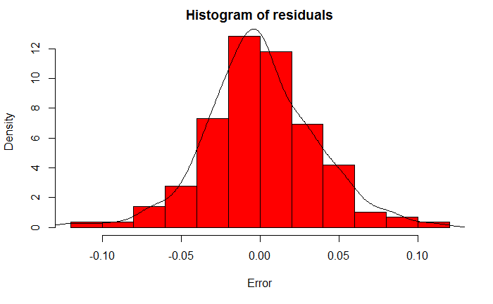

```r
hist(model$residuals,
     col='red',
     xlab = 'Error',
     main='Histogram of residuals',
     freq = FALSE)
lines(density(model$residuals))
```

since there is no problem with model we can forecast

Forecast forecast for next 48 month

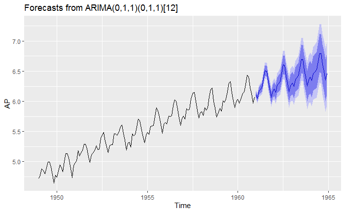

```r
library(ggplot2)
f <- forecast(model,48)
autoplot(f)
```

```r
accuracy(f)
```

```
                       ME       RMSE        MAE        MPE      MAPE      MASE       ACF1
Training set 0.0005730622 0.03504883 0.02626034 0.01098898 0.4752815 0.2169522 0.01443892
```

dark 80% confidence and light is 95% confidence standard accuracy measures have been computed